# CIS242_HW1_Shuyue_Yang

## CIS 242

## Spring 2022

## HOMEWORK ASSIGNMENT 1

This notebook contains some more advanced Python code.

You need to add a comment to each indicated cell explaining what the code in that cell is doing. You do NOT need to comment each line.

You should execute each cell even if there is no requirement to add a comment. You are welcome to add additional code or markdown cells as you find helpful.

You may use whatever external resources you like. If you borrow ANY text or code from a website, book, or other resource, you must cite it. Just noting the URL is fine.

#### Active notebooks (.ipynb files) or raw code (.py files) will NOT be accepted and no points will be given.

This assignment is worth **11 points**. You will lose 1/2 point for each missing or incorrect answer.

**The assignment is due at 11:00am on January 25th. Assignments submitted after that will lose 50% of the grade. Assignments submitted after midnight on February 1st will not be accepted.**

#### Many thanks to Sean Paddock of Rockhurst University for letting me steal his awesome notebooks

```python
%matplotlib inline

import numpy as np
import pandas as pd
import matplotlib.pyplot as plt
```

Now we’ll look at an example that has some real problems that you’ll likely experience all the time during your analysis and work.

So lets get started!

The data set that we're going to work with is a slice of http://stat-computing.org/dataexpo/2009/

### Hint to help you get the right answers

These questions are as straightforward as they look. However, you need to be clear about what you mean and you need the right level of detail. For example, if the code snippet was this:

[output not shown]

- A **great** answer would be: The code creates a dictionary with population data for two states over several years. The keys are the state names and the values are another dictionary with year and population as the key-value pair.
- Too **little** detail would be: it creates a dictionary with population data.
- Too **much** detail would be: The code creates a dictionary with population data for two states over several years. The keys are the state names of 'Nevada' and 'Ohio" and the values are dictionaries with population information for the years 2001 and 2002 for Nevada and the years 2000, 2001, and 2002 for Ohio.

### 1. What is the code below doing? (1 point)

```python
# use the flight information to preset a list of column names
# create a DataFrame by reading a CSV file and embedding the preset column index
# index_col = False is used to force pandas to not use the first column as row index
# Cite from https://pandas.pydata.org/docs/reference/api/pandas.read_csv.html

cols = ['Year', 'Month', 'DayofMonth', 'DayOfWeek','DepTime', 'CRSDepTime', 'ArrTime', 'CRSArrTime',
        'UniqueCarrier', 'FlightNum', 'TailNum', 'ActualElapsedTime', 'CRSElapsedTime',
        'AirTime', 'ArrDelay', 'DepDelay', 'Origin', 'Dest', 'Distance', 'TaxiIn', 'TaxiOut',
        'Cancelled', 'CancellationCode', 'Diverted', 'CarrierDelay', 'WeatherDelay', 'NASDelay',
        'SecurityDelay', 'LateAircraftDelay']
df = pd.read_csv('june_airplane_data.csv', names= cols, index_col = False)
```

```python
# return the first 5 rows of the DataFrame (5 is the default of the head function)

df.head()
```

|  | Year | Month | DayofMonth | DayOfWeek | DepTime | CRSDepTime | ArrTime | CRSArrTime | UniqueCarrier | FlightNum | ... | TaxiIn | TaxiOut | Cancelled | CancellationCode | Diverted | CarrierDelay | WeatherDelay | NASDelay | SecurityDelay | LateAircraftDelay |
| --- | --- | --- | --- | --- | --- | --- | --- | --- | --- | --- | --- | --- | --- | --- | --- | --- | --- | --- | --- | --- | --- |
| 0 | 1994 | 6 | 5 | 7 | 1542.0 | 1540 | 1819.0 | 1815 | US | 236 | ... | NaN | NaN | 0 | NaN | 0 | NaN | NaN | NaN | NaN | NaN |
| 1 | 1994 | 6 | 6 | 1 | 1549.0 | 1540 | 1831.0 | 1815 | US | 236 | ... | NaN | NaN | 0 | NaN | 0 | NaN | NaN | NaN | NaN | NaN |
| 2 | 1994 | 6 | 7 | 2 | 1540.0 | 1540 | 1803.0 | 1815 | US | 236 | ... | NaN | NaN | 0 | NaN | 0 | NaN | NaN | NaN | NaN | NaN |
| 3 | 1994 | 6 | 8 | 3 | 1541.0 | 1540 | 1808.0 | 1815 | US | 236 | ... | NaN | NaN | 0 | NaN | 0 | NaN | NaN | NaN | NaN | NaN |
| 4 | 1994 | 6 | 9 | 4 | 1541.0 | 1540 | 1835.0 | 1815 | US | 236 | ... | NaN | NaN | 0 | NaN | 0 | NaN | NaN | NaN | NaN | NaN |

5 rows × 29 columns

```python
# compute the summary statistics of columns in the DataFrame
# Since the DataFrame has mixed data types, the default is to return only an analysis of numeric columns.
# The index will include count, mean, std, min, max, etc.
# Cite from https://pandas.pydata.org/docs/reference/api/pandas.DataFrame.describe.html

df.describe()
```

|  | Year | Month | DayofMonth | DayOfWeek | DepTime | CRSDepTime | ArrTime | CRSArrTime | FlightNum | TailNum | ... | TaxiIn | TaxiOut | Cancelled | CancellationCode | Diverted | CarrierDelay | WeatherDelay | NASDelay | SecurityDelay | LateAircraftDelay |
| --- | --- | --- | --- | --- | --- | --- | --- | --- | --- | --- | --- | --- | --- | --- | --- | --- | --- | --- | --- | --- | --- |
| count | 426490.0 | 426490.0 | 426490.000000 | 426490.000000 | 423805.000000 | 426490.000000 | 422641.000000 | 426490.000000 | 426490.000000 | 0.0 | ... | 0.0 | 0.0 | 426490.000000 | 0.0 | 426490.000000 | 0.0 | 0.0 | 0.0 | 0.0 | 0.0 |
| mean | 1994.0 | 6.0 | 15.520458 | 3.923185 | 1343.071375 | 1337.525309 | 1489.413914 | 1493.821825 | 901.690736 | NaN | ... | NaN | NaN | 0.006296 | NaN | 0.002729 | NaN | NaN | NaN | NaN | NaN |
| std | 0.0 | 0.0 | 8.670839 | 1.930781 | 474.274010 | 465.902464 | 489.868444 | 474.554100 | 593.512783 | NaN | ... | NaN | NaN | 0.079095 | NaN | 0.052171 | NaN | NaN | NaN | NaN | NaN |
| min | 1994.0 | 6.0 | 1.000000 | 1.000000 | 1.000000 | 5.000000 | 1.000000 | 1.000000 | 1.000000 | NaN | ... | NaN | NaN | 0.000000 | NaN | 0.000000 | NaN | NaN | NaN | NaN | NaN |
| 25% | 1994.0 | 6.0 | 8.000000 | 2.000000 | 930.000000 | 930.000000 | 1114.000000 | 1117.000000 | 407.000000 | NaN | ... | NaN | NaN | 0.000000 | NaN | 0.000000 | NaN | NaN | NaN | NaN | NaN |
| 50% | 1994.0 | 6.0 | 16.000000 | 4.000000 | 1330.000000 | 1328.000000 | 1517.000000 | 1520.000000 | 792.000000 | NaN | ... | NaN | NaN | 0.000000 | NaN | 0.000000 | NaN | NaN | NaN | NaN | NaN |
| 75% | 1994.0 | 6.0 | 23.000000 | 6.000000 | 1731.000000 | 1722.000000 | 1913.000000 | 1910.000000 | 1429.000000 | NaN | ... | NaN | NaN | 0.000000 | NaN | 0.000000 | NaN | NaN | NaN | NaN | NaN |
| max | 1994.0 | 6.0 | 30.000000 | 7.000000 | 2400.000000 | 2359.000000 | 2400.000000 | 2400.000000 | 3219.000000 | NaN | ... | NaN | NaN | 1.000000 | NaN | 1.000000 | NaN | NaN | NaN | NaN | NaN |

8 rows × 26 columns

Now we've got a new issue, we've got a problem with our date time that we'd like to merge. There are two ways to do this, I'll show you the easiest one - the other one would involve combining them into one column then parsing the results. Let's do it the easier way with read_csv. We can specify parse dates as a dictionary where we map the columns to a date time list.

### 2. What is the code below doing? (1 point)

```python
# use a dictionary to combine columns 'Year' & 'Month' & 'DayofMonth' as a whole
# The key is named as 'Date', the values are the merged date format
# update the DataFrame by rereading the CSV file with merged data

df = pd.read_csv('june_airplane_data.csv', parse_dates={'Date':['Year','Month','DayofMonth']}, names= cols, index_col = False)
```

```python
# return the first 5 rows of the updated DataFrame (5 is the default of the head function)

df.head()
```

|  | Date | DayOfWeek | DepTime | CRSDepTime | ArrTime | CRSArrTime | UniqueCarrier | FlightNum | TailNum | ActualElapsedTime | ... | TaxiIn | TaxiOut | Cancelled | CancellationCode | Diverted | CarrierDelay | WeatherDelay | NASDelay | SecurityDelay | LateAircraftDelay |
| --- | --- | --- | --- | --- | --- | --- | --- | --- | --- | --- | --- | --- | --- | --- | --- | --- | --- | --- | --- | --- | --- |
| 0 | 1994-06-05 | 7 | 1542.0 | 1540 | 1819.0 | 1815 | US | 236 | NaN | 157.0 | ... | NaN | NaN | 0 | NaN | 0 | NaN | NaN | NaN | NaN | NaN |
| 1 | 1994-06-06 | 1 | 1549.0 | 1540 | 1831.0 | 1815 | US | 236 | NaN | 162.0 | ... | NaN | NaN | 0 | NaN | 0 | NaN | NaN | NaN | NaN | NaN |
| 2 | 1994-06-07 | 2 | 1540.0 | 1540 | 1803.0 | 1815 | US | 236 | NaN | 143.0 | ... | NaN | NaN | 0 | NaN | 0 | NaN | NaN | NaN | NaN | NaN |
| 3 | 1994-06-08 | 3 | 1541.0 | 1540 | 1808.0 | 1815 | US | 236 | NaN | 147.0 | ... | NaN | NaN | 0 | NaN | 0 | NaN | NaN | NaN | NaN | NaN |
| 4 | 1994-06-09 | 4 | 1541.0 | 1540 | 1835.0 | 1815 | US | 236 | NaN | 174.0 | ... | NaN | NaN | 0 | NaN | 0 | NaN | NaN | NaN | NaN | NaN |

5 rows × 27 columns

Now let's start by setting up something to group things by time. We can see we've got a departure time and arrival time column that is going to be useful. Right now they're in Army time format. It may be nice to break them up into 6 hour chunks, from midnight to 6 am, 6 to noon, noon to 1800, then 1800 to midnight

Introducing the 'cut' function

### 3. What is the code below doing? (1 point)

```python
# use a list of numbers to divide 24 hours into 4 time ranges with an equal 6-hour interval
# use a list of categorical labels to name the 4 time ranges
# create two new columns in the DataFrame to segment the numerical departure and arrival time into categorical labels according to the time ranges
# convert the two columns to categorical type

ranges = [0,600,1200,1800,2400]
labels = ['Early Morning','Morning','Early Afternoon','Evening']
df['DepTime2'] = pd.cut(df.DepTime, ranges, labels=labels).astype('category')
df['ArrTime2'] = pd.cut(df.ArrTime, ranges, labels=labels).astype('category')
```

```python
# return the first 5 rows of the updated DataFrame (5 is the default of the head function)

df.head()
```

|  | Date | DayOfWeek | DepTime | CRSDepTime | ArrTime | CRSArrTime | UniqueCarrier | FlightNum | TailNum | ActualElapsedTime | ... | Cancelled | CancellationCode | Diverted | CarrierDelay | WeatherDelay | NASDelay | SecurityDelay | LateAircraftDelay | DepTime2 | ArrTime2 |
| --- | --- | --- | --- | --- | --- | --- | --- | --- | --- | --- | --- | --- | --- | --- | --- | --- | --- | --- | --- | --- | --- |
| 0 | 1994-06-05 | 7 | 1542.0 | 1540 | 1819.0 | 1815 | US | 236 | NaN | 157.0 | ... | 0 | NaN | 0 | NaN | NaN | NaN | NaN | NaN | Early Afternoon | Evening |
| 1 | 1994-06-06 | 1 | 1549.0 | 1540 | 1831.0 | 1815 | US | 236 | NaN | 162.0 | ... | 0 | NaN | 0 | NaN | NaN | NaN | NaN | NaN | Early Afternoon | Evening |
| 2 | 1994-06-07 | 2 | 1540.0 | 1540 | 1803.0 | 1815 | US | 236 | NaN | 143.0 | ... | 0 | NaN | 0 | NaN | NaN | NaN | NaN | NaN | Early Afternoon | Evening |
| 3 | 1994-06-08 | 3 | 1541.0 | 1540 | 1808.0 | 1815 | US | 236 | NaN | 147.0 | ... | 0 | NaN | 0 | NaN | NaN | NaN | NaN | NaN | Early Afternoon | Evening |
| 4 | 1994-06-09 | 4 | 1541.0 | 1540 | 1835.0 | 1815 | US | 236 | NaN | 174.0 | ... | 0 | NaN | 0 | NaN | NaN | NaN | NaN | NaN | Early Afternoon | Evening |

5 rows × 29 columns

```python
# return the first 10 rows of column 'ArrTime2'

df.ArrTime2.head(10)
```

```
0    Evening
1    Evening
2    Evening
3    Evening
4    Evening
5    Evening
6    Evening
7    Evening
8    Evening
9    Evening
Name: ArrTime2, dtype: category
Categories (4, object): ['Early Morning' < 'Morning' < 'Early Afternoon' < 'Evening']
```

Now categorical data is different than what we're used to, we can see that it has a hierarchy. There's things that are less than other things and therefore is ordered. This can come in handy in certain types of analysis.

Really what this allows us to do is describe the data in terms of those categories

```python
# compute the summary statistics of column 'DepTime2' & 'ArrTime2'
# Since these two columns have a categorical data type, the result's index will include count, unique, top, and freq.
# The top is the most common value. The freq is the most common value's frequency.
# Cite from https://pandas.pydata.org/docs/reference/api/pandas.DataFrame.describe.html

df[['DepTime2','ArrTime2']].describe()
```

|  | DepTime2 | ArrTime2 |
| --- | --- | --- |
| count | 423805 | 422641 |
| unique | 4 | 4 |
| top | Morning | Early Afternoon |
| freq | 163514 | 156806 |

Let's try to answer a specific question. When flights leave and arrive, what is the average delay time? Now these are for actual departure and arrival times, not the scheduled ones. That's a different time entirely.

For example, If a flight leaves in the early morning and arrives in the early morning, what is the typical delay? Is there a longer departure delay or arrival delay?

### 4. What is the code below doing? (1 point)

```python
# groupby the departure and arrival time based on the 4 time ranges(first departure then arrival)
# print the mean of the departure delay time and arrival delay time according to groups
# use dictionary to return both the mean and standard deviation of the arrival delay time and departure delay time according to groups
# The keys are the two types of delay, the values are means and sds generated by NumPy functions

print(df.groupby(['DepTime2', 'ArrTime2'])[['DepDelay','ArrDelay']].mean())
df.groupby(['DepTime2', 'ArrTime2']).agg({'ArrDelay':[np.mean, np.std], 'DepDelay':[np.mean, np.std]})
```

```
                                  DepDelay   ArrDelay
DepTime2        ArrTime2
Early Morning   Early Morning    43.804627  42.069923
                Morning           2.578566   2.109582
                Early Afternoon        NaN        NaN
                Evening          64.000000  61.333333
Morning         Early Morning          NaN        NaN
                Morning           2.367489   0.664017
                Early Afternoon   3.769618   4.102513
                Evening           5.411565  12.923469
Early Afternoon Early Morning     8.890995  14.450237
                Morning           4.896104   2.480519
                Early Afternoon   5.166529   4.571237
                Evening           7.632955  11.082200
Evening         Early Morning    36.956347  42.037799
                Morning           5.464702   7.629198
                Early Afternoon  29.142857  22.500000
                Evening          13.668750  12.756813
```

| DepTime2 | ArrTime2 | ArrDelay mean | ArrDelay std | DepDelay mean | DepDelay std |
| --- | --- | --- | --- | --- | --- |
| Early Morning | Early Morning | 42.069923 | 91.241073 | 43.804627 | 91.836738 |
|  | Morning | 2.109582 | 18.436171 | 2.578566 | 16.595306 |
|  | Early Afternoon | NaN | NaN | NaN | NaN |
|  | Evening | 61.333333 | 5.507571 | 64.000000 | 8.888194 |
| Morning | Early Morning | NaN | NaN | NaN | NaN |
|  | Morning | 0.664017 | 13.453101 | 2.367489 | 10.216042 |
|  | Early Afternoon | 4.102513 | 17.172703 | 3.769618 | 12.482494 |
|  | Evening | 12.923469 | 24.192638 | 5.411565 | 15.704599 |
| Early Afternoon | Early Morning | 14.450237 | 42.653210 | 8.890995 | 27.347542 |
|  | Morning | 2.480519 | 11.084140 | 4.896104 | 8.718680 |
|  | Early Afternoon | 4.571237 | 18.710938 | 5.166529 | 14.861790 |
|  | Evening | 11.082200 | 28.073863 | 7.632955 | 19.324282 |
| Evening | Early Morning | 42.037799 | 74.136225 | 36.956347 | 65.635363 |
|  | Morning | 7.629198 | 17.129908 | 5.464702 | 12.298888 |
|  | Early Afternoon | 22.500000 | 30.933552 | 29.142857 | 32.229602 |
|  | Evening | 12.756813 | 34.126398 | 13.668750 | 39.551075 |

#### Can we rank these data by average delay time?

We want to use total delay time for our ranking.

### 5. What is the code below doing? (1 point)

```python
# create a new column to compute the total delay time of each flight(sum of the arrival delay and departure delay time)
# create a new column to segment the numerical scheduled departure time into categorical labels according to the 4 time ranges

df['TotalDelay'] = df.ArrDelay + df.DepDelay
df['ScheduledDepTime'] = pd.cut(df.CRSDepTime, ranges, labels=labels)

# generate a function of returning a DataFrame with a new column that calculates the average total delay time for each flight

def average_delay(dataframe):
    dataframe['AvgFlightDelay'] = dataframe.TotalDelay.mean()
    return dataframe

# groupby the flight number and apply the function of returning a DataFrame with calculating the average total delay time
# print the last 10 rows of the DataFrame

avg_delayed = df.groupby('FlightNum').apply(average_delay)
print(avg_delayed.tail(10))
```

```
             Date  DayOfWeek  DepTime  CRSDepTime  ArrTime  CRSArrTime  \
426480 1994-06-08          3   1500.0        1435   1554.0        1530
426481 1994-06-09          4   1445.0        1435   1532.0        1530
426482 1994-06-10          5   1438.0        1435   1531.0        1530
426483 1994-06-12          7   1435.0        1435   1524.0        1530
426484 1994-06-13          1   1433.0        1435   1522.0        1530
426485 1994-06-14          2   1435.0        1435   1528.0        1530
426486 1994-06-15          3   1446.0        1435   1537.0        1530
426487 1994-06-16          4   1440.0        1435   1530.0        1530
426488 1994-06-17          5   1456.0        1435   1554.0        1530
426489 1994-06-19          7   1443.0        1435   1540.0        1530

       UniqueCarrier  FlightNum  TailNum  ActualElapsedTime  ...  \
426480            CO       1720      NaN               54.0  ...
426481            CO       1720      NaN               47.0  ...
```

[output cut: 46 more lines]

### 6. What is the code below doing? (1 point)

```python
# generate a function of returning a DataFrame with a new column that ranks the data in a selected column in the imported DataFrame
# first sort the column data in descending order
# then create a new column to show the ranking of the data in the selected column

def ranking(dataframe, column):
    dataframe.sort_values(column, ascending=False,inplace=True)
    dataframe[column + "Rank"] = np.arange(len(dataframe)) + 1
    return dataframe

# groupby the sceduled departure time and apply the function of ranking the average total delay time
# return the rows in which their average total delay time has a ranking of 1

avg_delayed_ranked = avg_delayed.groupby('ScheduledDepTime').apply(lambda x: ranking(x, 'AvgFlightDelay'))
avg_delayed_ranked[avg_delayed_ranked.AvgFlightDelayRank == 1]
```

[output not shown]

4 rows × 33 columns

```python
# return the first 5 rows of column 'AvgFlightDelayRank', representing the highest 5 ranking of average total delay time
# (5 is the default of the head function)

avg_delayed_ranked.AvgFlightDelayRank.head()
```

```
ScheduledDepTime
Early Morning     269530    1
                  269529    2
                  269532    3
                  269533    4
                  269534    5
Name: AvgFlightDelayRank, dtype: int64
```

```python
# show the number of flights for each average delay time ranking

pd.crosstab(avg_delayed_ranked.AvgFlightDelayRank, all )
```

| col_0 AvgFlightDelayRank | <built-in function all> |
| --- | --- |
| 1 | 4 |
| 2 | 4 |
| 3 | 4 |
| 4 | 4 |
| 5 | 4 |
| ... | ... |
| 166774 | 1 |
| 166775 | 1 |
| 166776 | 1 |
| 166777 | 1 |
| 166778 | 1 |

166778 rows × 1 columns

```python
# create a DataFrame by reading the data in an CSV file
# print the type and shape of the DataFrame
# return the first 10 rows of the DataFrame

df = pd.read_csv('raw_running_data.csv')
print(type(df))
print(df.shape)
df.head(10)
```

```
<class 'pandas.core.frame.DataFrame'>
(81, 3)
```

|  | Date | Miles | Time |
| --- | --- | --- | --- |
| 0 | 8/2/14 | 1.70 | NaN |
| 1 | 8/3/14 | 1.40 | NaN |
| 2 | 8/4/14 | 2.10 | NaN |
| 3 | 8/6/14 | 2.38 | NaN |
| 4 | 8/7/14 | 2.30 | NaN |
| 5 | 8/8/14 | 3.40 | NaN |
| 6 | 8/9/14 | 2.50 | NaN |
| 7 | 8/10/14 | 3.36 | 0:28:37 |
| 8 | 8/11/14 | 1.67 | 0:13:07 |
| 9 | 8/12/14 | 1.42 | 0:10:35 |

```python
# return the data type of each column in the DataFrame

df.dtypes
```

```
Date      object
Miles    float64
Time      object
dtype: object
```

Now for a little background on this dataset. This is exercise data from august 1st 2014 to January 1st 2015. During these several months the runner recorded the distance every time he ran and recorded the time the majority of the time that took as well.

```python
# print the name of each column
# print the first 5 rows of the DataFrame (5 is the default of the head function)
# return the first 5 rows of column 'Date'

print(df.columns)
print(df.head())
df['Date'].head()
```

```
Index(['Date', 'Miles', 'Time'], dtype='object')
     Date  Miles Time
0  8/2/14   1.70  NaN
1  8/3/14   1.40  NaN
2  8/4/14   2.10  NaN
3  8/6/14   2.38  NaN
4  8/7/14   2.30  NaN
```

```
0    8/2/14
1    8/3/14
2    8/4/14
3    8/6/14
4    8/7/14
Name: Date, dtype: object
```

### 7. What is the code below doing? (1 point)

```python
# create a DataFrame by reading a csv file and convert column 'Date' into the system date format
# set column 'Date' as the index column of the DataFrame
# return the first 10 rows of the DataFrame

df = pd.read_csv('raw_running_data.csv', parse_dates=['Date'])
df.set_index('Date', inplace=True)
df.head(10)
```

| Date | Miles | Time |
| --- | --- | --- |
| 2014-08-02 | 1.70 | NaN |
| 2014-08-03 | 1.40 | NaN |
| 2014-08-04 | 2.10 | NaN |
| 2014-08-06 | 2.38 | NaN |
| 2014-08-07 | 2.30 | NaN |
| 2014-08-08 | 3.40 | NaN |
| 2014-08-09 | 2.50 | NaN |
| 2014-08-10 | 3.36 | 0:28:37 |
| 2014-08-11 | 1.67 | 0:13:07 |
| 2014-08-12 | 1.42 | 0:10:35 |

Let’s go ahead and plot it.

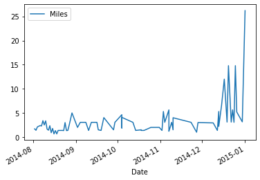

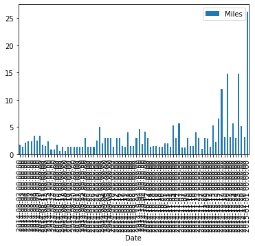

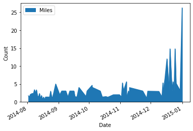

```python
# display a line graph that shows the relation between date and miles

df.plot()
plt.show()

# display a bar plot of date vs. miles

df.plot(kind='bar')
plt.show()

# display an area graph of date vs. miles (with area in solid blue)
# label the y-axis as 'Count'

df.plot(kind='area')
plt.ylabel("Count")
plt.show()
```

```python
# compute the summary statistics of column 'Miles'

df.describe()
```

|  | Miles |
| --- | --- |
| count | 81.000000 |
| mean | 3.137531 |
| std | 3.634519 |
| min | 0.650000 |
| 25% | 1.370000 |
| 50% | 2.100000 |
| 75% | 3.050000 |
| max | 26.200000 |

There's something very irregular about these data.

Well the problem is that our data is recorded on inconsistent days. You’ll see dates that have multiple entries and others that don’t have any entry at all. For instance November.

### 8. What is the code below doing? (1 point)

```python
# return the rows in which the running exercise was taken during November 2014

# FutureWarning: Indexing a DataFrame with a datetimelike index using a single string to slice the rows, like `frame[string]`, is deprecated and will be removed in a future version. Use `frame.loc[string]` instead.

df.loc['2014-11']
```

| Date | Miles | Time |
| --- | --- | --- |
| 2014-11-02 | 1.37 | 0:08:43 |
| 2014-11-03 | 5.30 | 0:39:26 |
| 2014-11-04 | 3.05 | 0:22:12 |
| 2014-11-07 | 5.63 | 0:49:05 |
| 2014-11-07 | 1.26 | NaN |
| 2014-11-07 | 1.20 | NaN |
| 2014-11-09 | 3.05 | 0:22:36 |
| 2014-11-10 | 1.50 | 0:09:00 |
| 2014-11-10 | 1.50 | 0:11:33 |
| 2014-11-10 | 4.00 | NaN |
| 2014-11-23 | 3.05 | 0:22:35 |
| 2014-11-27 | 1.00 | NaN |
| 2014-11-28 | 3.00 | NaN |

```python
# return the count of rows in which the running exercise was taken during November 2014

# FutureWarning: Indexing a DataFrame with a datetimelike index using a single string to slice the rows, like `frame[string]`, is deprecated and will be removed in a future version. Use `frame.loc[string]` instead.

len(df.loc['2014-11'])
```

```
13
```

This kind of thing comes up time and time again in data analysis. You’re analyzing some data trying to get patterns out of it, you notice some weird inconsistencies and then realize the data was collected in a strange way. However pandas makes it easy to fill in those gaps.

### 9. What is the code below doing? (1 point)

```python
# set a time interval and print it
# create a new DataFrame to get a list of dates that are in the time interval
# print the shape of the DataFrame to show the count of the list of dates
# return the first 5 dates

from datetime import datetime
start = datetime(2014,8,2)
end = datetime(2015,1,1)
print(start, end)
d = pd.DataFrame(index=pd.date_range(start, end))
print(d.shape)
d.head()
```

```
2014-08-02 00:00:00 2015-01-01 00:00:00
(153, 0)
```

| 2014-08-02 |
| --- |
| 2014-08-03 |
| 2014-08-04 |
| 2014-08-05 |
| 2014-08-06 |

Of course there are multiple ways to perform this operation but let's describe it using joins to illustrate import concepts.

#### Joins. A join is like a SQL join or a venn diagram.

[figure not shown]

```python
# return the first 10 rows of the data in which the date of running exercise was in the time interval

df.head(10)
```

| Date | Miles | Time |
| --- | --- | --- |
| 2014-08-02 | 1.70 | NaN |
| 2014-08-03 | 1.40 | NaN |
| 2014-08-04 | 2.10 | NaN |
| 2014-08-06 | 2.38 | NaN |
| 2014-08-07 | 2.30 | NaN |
| 2014-08-08 | 3.40 | NaN |
| 2014-08-09 | 2.50 | NaN |
| 2014-08-10 | 3.36 | 0:28:37 |
| 2014-08-11 | 1.67 | 0:13:07 |
| 2014-08-12 | 1.42 | 0:10:35 |

### 10. What is the code below doing? (1 point)

```python
# outer join the DataFrame that reads from the csv file with the DataFrame that has a list of dates in the time interval
# print the shape of the joined DataFrame
# return the first 5 rows of the joined DataFrame

df = df.join(d, how='outer')
print(df.shape)
df.head()
```

```
(166, 2)
```

|  | Miles | Time |
| --- | --- | --- |
| 2014-08-02 | 1.70 | NaN |
| 2014-08-03 | 1.40 | NaN |
| 2014-08-04 | 2.10 | NaN |
| 2014-08-05 | NaN | NaN |
| 2014-08-06 | 2.38 | NaN |

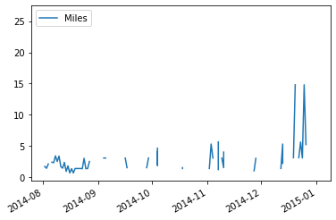

```python
# display a plot of date vs. miles based on the joined DataFrame
# there are many gaps in the plot since some dates do not have a corresponding mile amount

df.plot()
plt.show()
```

### 11. What is the code below doing? (1 point)

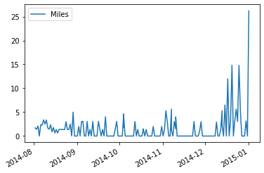

```python
# fill in the gaps (dates do not have a corresponding mile amount) with an amount of 0
# display a plot of date vs. miles that has no gaps

df.Miles.fillna(0,inplace=True)

df.plot()
plt.show()
```